# ชื่อ ปรียานุช

# นามสกุล สุภาสืบ

# รหัสนักศึกษา 61070306

# Lab AI for Medicine : Heart Dataset

ชุดข้อมูลโรคหัวใจ ประกอบด้วยฐานข้อมูล 4 ฐานข้อมูลเกี่ยวกับการวินิจฉัยโรคหัวใจ แอตทริบิวต์ทั้งหมดมีค่าเป็นตัวเลข ข้อมูลถูกรวบรวมจากไฟล์ 4 สถานที่ดังต่อไปนี้:

```
  1 มูลนิธิคลีฟแลนด์คลินิก (cleveland.data)
  2 สถาบันโรคหัวใจแห่งฮังการีบูดาเปสต์ (Hungarian.data)
  3 V.A. ศูนย์การแพทย์ลองบีชแคลิฟอร์เนีย (long-beach-va.data)
  4 โรงพยาบาลมหาวิทยาลัยซูริกประเทศสวิตเซอร์แลนด์ (ข้อมูลสวิตเซอร์แลนด์)
```

แต่ละฐานข้อมูลมีรูปแบบเดียวกัน ในขณะที่ฐานข้อมูลมี 76 แอตทริบิวต์ มีเพียง 14 รายการเท่านั้นที่ใช้จริง

ข้อมูลโรคหัวใจชุดนี้มี 76 แอตทริบิวต์ ซึ่งมีรายละเอียดดังนี้

1 id: patient identification number

2 ccf: social security number (I replaced this with a dummy value of 0)

3 age: age in years

4 sex: sex (1 = male; 0 = female)

5 painloc: chest pain location (1 = substernal; 0 = otherwise)

6 painexer (1 = provoked by exertion; 0 = otherwise)

7 relrest (1 = relieved after rest; 0 = otherwise)

8 pncaden (sum of 5, 6, and 7)

9 cp: chest pain type -- Value 1: typical angina -- Value 2: atypical angina -- Value 3: non-anginal pain -- Value 4: asymptomatic

10 trestbps: resting blood pressure (in mm Hg on admission to the hospital)

11 htn

12 chol: serum cholestoral in mg/dl

13 smoke: I believe this is 1 = yes; 0 = no (is or is not a smoker)

14 cigs (cigarettes per day)

15 years (number of years as a smoker)

16 fbs: (fasting blood sugar > 120 mg/dl) (1 = true; 0 = false)

17 dm (1 = history of diabetes; 0 = no such history)

18 famhist: family history of coronary artery disease (1 = yes; 0 = no)

19 restecg: resting electrocardiographic results -- Value 0: normal -- Value 1: having ST-T wave abnormality (T wave inversions and/or ST elevation or depression of > 0.05 mV) -- Value 2: showing probable or definite left ventricular hypertrophy by Estes' criteria

20 ekgmo (month of exercise ECG reading)

21 ekgday(day of exercise ECG reading)

22 ekgyr (year of exercise ECG reading)

23 dig (digitalis used furing exercise ECG: 1 = yes; 0 = no)

24 prop (Beta blocker used during exercise ECG: 1 = yes; 0 = no)

25 nitr (nitrates used during exercise ECG: 1 = yes; 0 = no)

26 pro (calcium channel blocker used during exercise ECG: 1 = yes; 0 = no)

27 diuretic (diuretic used used during exercise ECG: 1 = yes; 0 = no)

28 proto: exercise protocol 1 = Bruce 2 = Kottus 3 = McHenry 4 = fast Balke 5 = Balke 6 = Noughton 7 = bike 150 kpa min/min (Not sure if "kpa min/min" is what was written!) 8 = bike 125 kpa min/min 9 = bike 100 kpa min/min 10 = bike 75 kpa min/min 11 = bike 50 kpa min/min 12 = arm ergometer

29 thaldur: duration of exercise test in minutes

30 thaltime: time when ST measure depression was noted

31 met: mets achieved

32 thalach: maximum heart rate achieved

33 thalrest: resting heart rate

34 tpeakbps: peak exercise blood pressure (first of 2 parts)

35 tpeakbpd: peak exercise blood pressure (second of 2 parts)

36 dummy

37 trestbpd: resting blood pressure

38 exang: exercise induced angina (1 = yes; 0 = no)

39 xhypo: (1 = yes; 0 = no)

40 oldpeak = ST depression induced by exercise relative to rest

41 slope: the slope of the peak exercise ST segment -- Value 1: upsloping -- Value 2: flat -- Value 3: downsloping

42 rldv5: height at rest

43 rldv5e: height at peak exercise

44 ca: number of major vessels (0-3) colored by flourosopy

45 restckm: irrelevant

46 exerckm: irrelevant

47 restef: rest raidonuclid (sp?) ejection fraction

48 restwm: rest wall (sp?) motion abnormality 0 = none 1 = mild or moderate 2 = moderate or severe 3 = akinesis or dyskmem (sp?)

49 exeref: exercise radinalid (sp?) ejection fraction

50 exerwm: exercise wall (sp?) motion

51 thal: 3 = normal; 6 = fixed defect; 7 = reversable defect

52 thalsev: not used

53 thalpul: not used

54 earlobe: not used

55 cmo: month of cardiac cath (sp?) (perhaps "call")

56 cday: day of cardiac cath (sp?)

57 cyr: year of cardiac cath (sp?)

58 num: diagnosis of heart disease (angiographic disease status) -- Value 0: < 50% diameter narrowing -- Value 1: > 50% diameter narrowing (in any major vessel: attributes 59 through 68 are vessels)

59 lmt

60 ladprox

61 laddist

62 diag

63 cxmain

64 ramus

65 om1

66 om2

67 rcaprox

68 rcadist

69 lvx1: not used

70 lvx2: not used

71 lvx3: not used

72 lvx4: not used

73 lvf: not used

74 cathef: not used

75 junk: not used

76 name: last name of patient (I replaced this with the dummy string "name")

จำนวนข้อมูลโรคหัวใจมีดังนี้ :

- Cleveland : 303 Records
- Hungarian : 294 Records
- Switzerland : 123 Records
- Long Beach VA : 200 Records

Attribute Information: -- Only 14 used

```
  -- 1. #3  (age)
  -- 2. #4  (sex)
  -- 3. #9  (cp)
  -- 4. #10 (trestbps)
  -- 5. #12 (chol)
  -- 6. #16 (fbs)
  -- 7. #19 (restecg)
  -- 8. #32 (thalach)
  -- 9. #38 (exang)
  -- 10. #40 (oldpeak)
  -- 11. #41 (slope)
  -- 12. #44 (ca)
  -- 13. #51 (thal)
  -- 14. #58 (num)       (the predicted attribute)
```

```python
#! pip install tensorflow
#! pip install keras
```

```python
import pandas as pd
import numpy as np
import seaborn as sns
import sklearn.model_selection as mod
import sklearn.neighbors as nei
from sklearn.neighbors import KNeighborsClassifier
from sklearn.model_selection import KFold
from sklearn.model_selection import StratifiedKFold
from sklearn.model_selection import LeaveOneOut
from sklearn import metrics
from sklearn.metrics import accuracy_score, confusion_matrix, roc_curve, roc_auc_score, classification_report, precision_recall_curve, average_precision_score
from sklearn.naive_bayes import MultinomialNB
from sklearn.model_selection import cross_val_score
from sklearn.feature_selection import RFECV
from sklearn.svm import SVC
import matplotlib.pyplot as plt
import statsmodels.api as sm
from sklearn.linear_model import LogisticRegression
from sklearn.metrics import classification_report
from sklearn.metrics import confusion_matrix
from sklearn.metrics import *
import operator
```

```python
%matplotlib inline
import matplotlib
from matplotlib import pyplot
from sklearn import preprocessing
%matplotlib inline
pd.set_option('display.max_rows', 500)
pd.set_option('display.max_columns', 500)
pd.set_option('display.width', 1000)
import warnings
warnings.filterwarnings('ignore')
from sklearn.preprocessing import LabelEncoder
from scipy.stats import chi2_contingency
from scipy.stats import chi2
from sklearn.feature_selection import SelectKBest
from sklearn.feature_selection import chi2 as sklearn_chi2
```

```python
import numpy as np
import pandas as pd
import matplotlib as plt
import seaborn as sns
from sklearn.model_selection import train_test_split
from sklearn import svm
from sklearn import metrics
from sklearn.svm import SVC
from sklearn.metrics import classification_report, confusion_matrix
```

```python
import keras
from keras.models import Sequential
from keras.layers import Dense
from tensorflow.keras.models import Sequential
from tensorflow.keras.layers import Dense, Dropout, BatchNormalization
import tensorflow as tf
```

# วัตถุประสงค์

โครงการนี้มีวัตถุประสงค์เพื่อช่วยให้ผู้เชี่ยวชาญด้านสุขภาพทำการวินิจฉัยได้ง่ายขึ้นโดยใช้เทคนิค Machine Learning เพื่อเป็นการเชื่อมกันระหว่างความรู้กับชุดข้อมูลที่ทำการบันทึกไว้สามารถนำไปใช้ประโยขน์ได้ ดังนั้นในการทดลองนี้เราจะนำเทคนิค Machine learning มาประยุกต์ใช้กับ Heart Dataset

Import and Loading Dataset

```python
df = pd.read_csv('Heart_UCI_data_Excel.csv')
df
```

|  | ID | SSN | Age | Sex | Painloc | Painexer | Relrest | Pncaden | CP: Chest pain type | Trestbps | HTN | Chol | Smoke | Cigarettes | Years | FBS | DM | FAMhist | Restecg | Ekgmo | Ekgday | Ekgyr | Dig | Prop | Nitr | Pro | Diuretic | Proto | Thaldur | … |
| --- | --- | --- | --- | --- | --- | --- | --- | --- | --- | --- | --- | --- | --- | --- | --- | --- | --- | --- | --- | --- | --- | --- | --- | --- | --- | --- | --- | --- | --- | --- |
| 0 | 1 | 15943882 | 63 | 1 | -9 | -9 | -9 | -27 | 1 | 145 | 1 | 233.00 | -9 | 50 | 20 | 1 | 0 | 1 | 2 | 2 | 3 | 1981 | 0 | 0 | 0 | 0 | 0 | 1 | 10.5 | … |
| 1 | 2 | 15964847 | 67 | 1 | -9 | -9 | -9 | -27 | 4 | 160 | 1 | 286.00 | -9 | 40 | 40 | 0 | 0 | 1 | 2 | 3 | 5 | 1981 | 0 | 1 | 0 | 0 | 0 | 1 | 9.5 | … |
| 2 | 3 | 15952199 | 67 | 1 | -9 | -9 | -9 | -27 | 4 | 120 | 1 | 229.00 | -9 | 20 | 35 | 0 | 0 | 1 | 2 | 2 | 19 | 1981 | 0 | 1 | 0 | 0 | 0 | 1 | 8.5 | … |
| 3 | 4 | 15929464 | 37 | 1 | -9 | -9 | -9 | -27 | 3 | 130 | 0 | 250.00 | -9 | 0 | 0 | 0 | 0 | 1 | 0 | 2 | 13 | 1981 | 0 | 1 | 0 | 0 | 0 | 1 | 13.0 | … |
| 4 | 6 | 11961207 | 41 | 0 | -9 | -9 | -9 | -27 | 2 | 130 | 1 | 204.00 | -9 | 0 | 0 | 0 | 0 | 1 | 2 | 2 | 7 | 1981 | 0 | 0 | 0 | 0 | 0 | 1 | 7.0 | … |
| ... | ... | ... | ... | ... | ... | ... | ... | ... | ... | ... | ... | ... | ... | ... | ... | ... | ... | ... | ... | ... | ... | ... | ... | ... | ... | ... | ... | ... | ... | … |
| 1536 | 1666 | 24309 | 47 | 0 | 1 | -9 | -9 | -9 | 2 | 110 | 0 | 165.55 | -9 | -9 | -9 | 0 | 0 | -9 | 2 | 6 | 12 | 1989 | 0 | 0 | 1 | 1 | 0 | 100 | 11.0 | … |
| 1537 | 1667 | 22803 | 61 | 0 | 1 | -9 | -9 | -9 | 1 | 120 | 0 | 250.25 | -9 | -9 | -9 | 0 | 0 | -9 | 0 | 5 | 24 | 1989 | 0 | 1 | 1 | 1 | 0 | 25 | 1.0 | … |
| 1538 | 1668 | 13203 | 57 | 1 | 1 | -9 | -9 | -9 | 4 | 130 | 0 | 305.69 | -9 | -9 | -9 | 0 | 0 | -9 | 0 | 5 | 10 | 1989 | 0 | 0 | 0 | 0 | 0 | 100 | 10.0 | … |
| 1539 | 1669 | 14205 | 47 | 1 | 1 | -9 | -9 | -9 | 4 | 100 | 0 | 127.05 | -9 | -9 | -9 | 0 | 0 | -9 | 0 | 2 | 22 | 1989 | 0 | 0 | 0 | 0 | 0 | 100 | 10.0 | … |
| 1540 | 1670 | 15403 | 36 | 1 | 1 | -9 | -9 | -9 | 3 | 120 | 0 | 221.76 | -9 | -9 | -9 | 0 | 0 | -9 | 0 | 3 | 2 | 1989 | 0 | 0 | 0 | 0 | 0 | 150 | 19.0 | … |

1541 rows × 90 columns

# Check Null Value

```python
df.isnull().sum()
```

```
ID                     0
SSN                    0
Age                    0
Sex                    0
Painloc                0
Painexer               0
Relrest                0
Pncaden                0
CP: Chest pain type    0
Trestbps               0
HTN                    0
Chol                   0
Smoke                  0
Cigarettes             0
Years                  0
FBS                    0
DM                     0
FAMhist                0
Restecg                0
Ekgmo                  0
Ekgday                 0
Ekgyr                  0
Dig                    0
Prop                   0
Nitr                   0
Pro                    0
Diuretic               0
Proto                  0
Thaldur                0
Thaltime               0
Met                    0
Thalach                0
Thalrest               0
Tpeakbps               0
Tpeakbpd               0
Dummy                  0
Testbpd                0
Exang                  0
Xhypo                  0
Oldpeak                0
```

[output cut: 36 more lines]

```
Unnamed: 76            0
Unnamed: 77            0
Unnamed: 78            0
Unnamed: 79            0
Unnamed: 80            0
Unnamed: 81            0
Unnamed: 82            0
Unnamed: 83            0
Unnamed: 84            0
Unnamed: 85            0
Unnamed: 86            0
Unnamed: 87            0
Unnamed: 88            0
Name                   0
dtype: int64
```

เลือก drop column ที่ไม่ใช้ในการวิเคราะห์ข้อมูลออกก่อน

```python
df = df.drop(['ID','SSN','Thalsev', 'Thapul','Earlobe','Lvx1','Lvx2','Lvx3','Lvx4','Lvf','cathef','Junk'
              ,'Unnamed: 75','Unnamed: 76','Unnamed: 77','Unnamed: 78','Unnamed: 79','Unnamed: 80','Unnamed: 81'
              ,'Unnamed: 82','Unnamed: 83','Unnamed: 84','Unnamed: 85','Unnamed: 86','Unnamed: 87','Unnamed: 88','Name'], axis=1)
df
```

|  | Age | Sex | Painloc | Painexer | Relrest | Pncaden | CP: Chest pain type | Trestbps | HTN | Chol | Smoke | Cigarettes | Years | FBS | DM | FAMhist | Restecg | Ekgmo | Ekgday | Ekgyr | Dig | Prop | Nitr | Pro | Diuretic | Proto | Thaldur | Thaltime | Met | … |
| --- | --- | --- | --- | --- | --- | --- | --- | --- | --- | --- | --- | --- | --- | --- | --- | --- | --- | --- | --- | --- | --- | --- | --- | --- | --- | --- | --- | --- | --- | --- |
| 0 | 63 | 1 | -9 | -9 | -9 | -27 | 1 | 145 | 1 | 233.00 | -9 | 50 | 20 | 1 | 0 | 1 | 2 | 2 | 3 | 1981 | 0 | 0 | 0 | 0 | 0 | 1 | 10.5 | 6.0 | 13.0 | … |
| 1 | 67 | 1 | -9 | -9 | -9 | -27 | 4 | 160 | 1 | 286.00 | -9 | 40 | 40 | 0 | 0 | 1 | 2 | 3 | 5 | 1981 | 0 | 1 | 0 | 0 | 0 | 1 | 9.5 | 6.0 | 13.0 | … |
| 2 | 67 | 1 | -9 | -9 | -9 | -27 | 4 | 120 | 1 | 229.00 | -9 | 20 | 35 | 0 | 0 | 1 | 2 | 2 | 19 | 1981 | 0 | 1 | 0 | 0 | 0 | 1 | 8.5 | 6.0 | 10.0 | … |
| 3 | 37 | 1 | -9 | -9 | -9 | -27 | 3 | 130 | 0 | 250.00 | -9 | 0 | 0 | 0 | 0 | 1 | 0 | 2 | 13 | 1981 | 0 | 1 | 0 | 0 | 0 | 1 | 13.0 | 13.0 | 17.0 | … |
| 4 | 41 | 0 | -9 | -9 | -9 | -27 | 2 | 130 | 1 | 204.00 | -9 | 0 | 0 | 0 | 0 | 1 | 2 | 2 | 7 | 1981 | 0 | 0 | 0 | 0 | 0 | 1 | 7.0 | -9.0 | 9.0 | … |
| ... | ... | ... | ... | ... | ... | ... | ... | ... | ... | ... | ... | ... | ... | ... | ... | ... | ... | ... | ... | ... | ... | ... | ... | ... | ... | ... | ... | ... | ... | … |
| 1536 | 47 | 0 | 1 | -9 | -9 | -9 | 2 | 110 | 0 | 165.55 | -9 | -9 | -9 | 0 | 0 | -9 | 2 | 6 | 12 | 1989 | 0 | 0 | 1 | 1 | 0 | 100 | 11.0 | -9.0 | 5.0 | … |
| 1537 | 61 | 0 | 1 | -9 | -9 | -9 | 1 | 120 | 0 | 250.25 | -9 | -9 | -9 | 0 | 0 | -9 | 0 | 5 | 24 | 1989 | 0 | 1 | 1 | 1 | 0 | 25 | 1.0 | 1.0 | 1.5 | … |
| 1538 | 57 | 1 | 1 | -9 | -9 | -9 | 4 | 130 | 0 | 305.69 | -9 | -9 | -9 | 0 | 0 | -9 | 0 | 5 | 10 | 1989 | 0 | 0 | 0 | 0 | 0 | 100 | 10.0 | 4.0 | 5.0 | … |
| 1539 | 47 | 1 | 1 | -9 | -9 | -9 | 4 | 100 | 0 | 127.05 | -9 | -9 | -9 | 0 | 0 | -9 | 0 | 2 | 22 | 1989 | 0 | 0 | 0 | 0 | 0 | 100 | 10.0 | -9.0 | 5.0 | … |
| 1540 | 36 | 1 | 1 | -9 | -9 | -9 | 3 | 120 | 0 | 221.76 | -9 | -9 | -9 | 0 | 0 | -9 | 0 | 3 | 2 | 1989 | 0 | 0 | 0 | 0 | 0 | 150 | 19.0 | -9.0 | 7.5 | … |

1541 rows × 63 columns

```python
# df = df.drop(['ID','SSN','Thalsev', 'Thapul','Earlobe','Lvx1','Lvx2','Lvx3','Lvx4','Lvf','cathef','Junk'
#               ,'Unnamed: 75','Unnamed: 76','Unnamed: 77','Unnamed: 78','Unnamed: 79','Unnamed: 80','Unnamed: 81'
#               ,'Unnamed: 82','Unnamed: 83','Unnamed: 84','Unnamed: 85','Unnamed: 86','Unnamed: 87','Unnamed: 88','Name'], axis=1)
# df
```

```python
df.info()
```

```
<class 'pandas.core.frame.DataFrame'>
RangeIndex: 1541 entries, 0 to 1540
Data columns (total 63 columns):
 #   Column               Non-Null Count  Dtype
---  ------               --------------  -----
 0   Age                  1541 non-null   int64
 1   Sex                  1541 non-null   int64
 2   Painloc              1541 non-null   int64
 3   Painexer             1541 non-null   int64
 4   Relrest              1541 non-null   int64
 5   Pncaden              1541 non-null   int64
 6   CP: Chest pain type  1541 non-null   int64
 7   Trestbps             1541 non-null   int64
 8   HTN                  1541 non-null   int64
 9   Chol                 1541 non-null   float64
```

[output cut: 55 more lines]

# ตรวจสอบข้อมูลเพื่อจัดการ Missing Data

```python
df.head(15)
```

|  | Age | Sex | Painloc | Painexer | Relrest | Pncaden | CP: Chest pain type | Trestbps | HTN | Chol | Smoke | Cigarettes | Years | FBS | DM | FAMhist | Restecg | Ekgmo | Ekgday | Ekgyr | Dig | Prop | Nitr | Pro | Diuretic | Proto | Thaldur | Thaltime | Met | … |
| --- | --- | --- | --- | --- | --- | --- | --- | --- | --- | --- | --- | --- | --- | --- | --- | --- | --- | --- | --- | --- | --- | --- | --- | --- | --- | --- | --- | --- | --- | --- |
| 0 | 63 | 1 | -9 | -9 | -9 | -27 | 1 | 145 | 1 | 233.0 | -9 | 50 | 20 | 1 | 0 | 1 | 2 | 2 | 3 | 1981 | 0 | 0 | 0 | 0 | 0 | 1 | 10.5 | 6.0 | 13.0 | … |
| 1 | 67 | 1 | -9 | -9 | -9 | -27 | 4 | 160 | 1 | 286.0 | -9 | 40 | 40 | 0 | 0 | 1 | 2 | 3 | 5 | 1981 | 0 | 1 | 0 | 0 | 0 | 1 | 9.5 | 6.0 | 13.0 | … |
| 2 | 67 | 1 | -9 | -9 | -9 | -27 | 4 | 120 | 1 | 229.0 | -9 | 20 | 35 | 0 | 0 | 1 | 2 | 2 | 19 | 1981 | 0 | 1 | 0 | 0 | 0 | 1 | 8.5 | 6.0 | 10.0 | … |
| 3 | 37 | 1 | -9 | -9 | -9 | -27 | 3 | 130 | 0 | 250.0 | -9 | 0 | 0 | 0 | 0 | 1 | 0 | 2 | 13 | 1981 | 0 | 1 | 0 | 0 | 0 | 1 | 13.0 | 13.0 | 17.0 | … |
| 4 | 41 | 0 | -9 | -9 | -9 | -27 | 2 | 130 | 1 | 204.0 | -9 | 0 | 0 | 0 | 0 | 1 | 2 | 2 | 7 | 1981 | 0 | 0 | 0 | 0 | 0 | 1 | 7.0 | -9.0 | 9.0 | … |
| 5 | 56 | 1 | -9 | -9 | -9 | -27 | 2 | 120 | 1 | 236.0 | -9 | 20 | 20 | 0 | 0 | 1 | 0 | 3 | 9 | 1981 | 1 | 0 | 0 | 0 | 0 | 1 | 11.3 | -9.0 | 16.0 | … |
| 6 | 62 | 0 | -9 | -9 | -9 | -27 | 4 | 140 | 0 | 268.0 | -9 | 0 | 0 | 0 | 0 | 1 | 2 | 1 | 28 | 1981 | 0 | 0 | 0 | 0 | 0 | 1 | 6.0 | 6.0 | 7.0 | … |
| 7 | 57 | 0 | -9 | -9 | -9 | -27 | 4 | 120 | 1 | 354.0 | -9 | 0 | 0 | 0 | 0 | 1 | 0 | 7 | 20 | 1981 | 0 | 0 | 0 | 0 | 0 | 1 | 9.0 | 6.0 | 10.0 | … |
| 8 | 63 | 1 | -9 | -9 | -9 | -27 | 4 | 130 | 1 | 254.0 | -9 | 0 | 0 | 0 | 0 | 0 | 2 | 7 | 2 | 1981 | 0 | 1 | 1 | 0 | 0 | 1 | 8.0 | 8.0 | 9.0 | … |
| 9 | 53 | 1 | -9 | -9 | -9 | -27 | 4 | 140 | 0 | 203.0 | -9 | 20 | 25 | 1 | 0 | 1 | 2 | 7 | 3 | 1981 | 0 | 1 | 0 | 0 | 1 | 1 | 5.5 | 3.0 | 7.0 | … |
| 10 | 57 | 1 | -9 | -9 | -9 | -27 | 4 | 140 | 0 | 192.0 | -9 | 75 | 25 | 0 | 0 | 0 | 0 | 6 | 30 | 1981 | 0 | 0 | 0 | 0 | 0 | 1 | 8.2 | -9.0 | 9.0 | … |
| 11 | 56 | 0 | -9 | -9 | -9 | -27 | 2 | 140 | 0 | 294.0 | -9 | 0 | 0 | 0 | 0 | 0 | 2 | 1 | 16 | 1981 | 0 | 1 | 1 | 0 | 0 | 1 | 4.5 | 4.5 | 7.0 | … |
| 12 | 56 | 1 | -9 | -9 | -9 | -27 | 3 | 130 | 0 | 256.0 | -9 | 30 | 25 | 1 | 1 | 1 | 2 | 1 | 19 | 1981 | 0 | 0 | 0 | 0 | 0 | 1 | 13.0 | -9.0 | 16.0 | … |
| 13 | 44 | 1 | -9 | -9 | -9 | -27 | 2 | 120 | 1 | 263.0 | -9 | 50 | 30 | 0 | 0 | 1 | 0 | 5 | 20 | 1981 | 0 | 1 | 0 | 0 | 0 | 1 | 9.3 | -9.0 | 13.0 | … |
| 14 | 52 | 1 | -9 | -9 | -9 | -27 | 3 | 172 | 0 | 199.0 | -9 | 30 | 35 | 1 | 0 | 0 | 0 | 6 | 9 | 1981 | 0 | 0 | 0 | 0 | 0 | 1 | 12.5 | -9.0 | 18.0 | … |

เมื่อทำการเช็คค่า null แล้วไม่พบค่า null ในข้อมูล แต่เมื่อสังเกตจากข้อมูลใน dataframe ด้านบนจะสังเกตเห็นได้ว่าข้อมูลมีค่า valueแปลกๆปะปนมาด้วยจึงทำการเช็คค่า value ของทุกคอลัมน์อีกที

```python
def check(df):
    for i in df.columns:
        print('\n' + i + '\n')
        print(df[i].unique())
        print(df[i].value_counts())
        print('\n' + '-*'*40 )
```

```python
check(df)
```

```
Age

[63 67 37 41 56 62 57 53 44 52 48 54 49 64 58 60 50 66 43 40 69 59 42 55
 61 65 71 51 46 45 39 68 47 34 35 29 70 77 38 74 76 36 32 31 33 28 30 27
 20 26 25 72 75 73 78]
54    78
58    71
57    66
55    65
56    60
51    58
62    55
48    54
52    53
60    51
63    48
53    48
44    44
59    43
50    42
43    42
61    41
45    40
64    39
46    39
47    38
41    37
42    36
49    34
65    30
39    30
40    29
67    27
38    26
37    25
66    24
35    19
36    18
34    17
68    16
```

[output cut: 2213 more lines]

```
-*-*-*-*-*-*-*-*-*-*-*-*-*-*-*-*-*-*-*-*-*-*-*-*-*-*-*-*-*-*-*-*-*-*-*-*-*-*-*-*

Rcadist

[ 1  2 -9  3 -1  4  0]
 1    515
-9    496
-1    336
 2    166
 4     13
 3      9
 0      6
Name: Rcadist, dtype: int64

-*-*-*-*-*-*-*-*-*-*-*-*-*-*-*-*-*-*-*-*-*-*-*-*-*-*-*-*-*-*-*-*-*-*-*-*-*-*-*-*
```

จะเลือก

- drop column 'Painexer', 'Relrest','Smoke','Cigarettes','Years','FAMhist','Proto','Rldv5','Rldv5e','CA','Restckm','Exerckm','Restef','Restwm','Exeref', 'Exerwm','Thal','Diag','Ramus','Painloc','Pncaden','Diuretic','Slope','cMo','cDay','cYr','lmt','Ladprox','Laddist','Om1','Om2','RCaprox','Rcadist'  
  ทิ้งเนื่องจากมีค่า value เป็น -9 แสดงถึงค่า Null ที่มี null มากกว่า 200 ข้อมูล
- drop row ที่ไม่มีคอลัมน์ Age, Sex, DM,num:diagnosis เนื่องจากค่า value ภายในคอลัมน์มีค่า -9
- drop row num:diagnosis ที่ภายในคอลัมน์มีค่า value = 2,3,4 ซึ่งไม่มี value นี้อยู่จริง

```python
df = df.drop(['Painexer', 'Relrest','Smoke','Cigarettes','Years','FAMhist','Proto','Rldv5','Rldv5e'
              ,'CA','Restckm','Exerckm','Restef','Restwm','Exeref','Exerwm','Thal','Diag','Ramus',
             'Painloc','Pncaden','Diuretic','Slope','cMo','cDay','cYr','lmt','Ladprox','Laddist',
             'Om1','Om2','RCaprox','Rcadist'], axis=1)
df
```

|  | Age | Sex | CP: Chest pain type | Trestbps | HTN | Chol | FBS | DM | Restecg | Ekgmo | Ekgday | Ekgyr | Dig | Prop | Nitr | Pro | Thaldur | Thaltime | Met | Thalach | Thalrest | Tpeakbps | Tpeakbpd | Dummy | Testbpd | Exang | Xhypo | Oldpeak | num:diagnosis | … |
| --- | --- | --- | --- | --- | --- | --- | --- | --- | --- | --- | --- | --- | --- | --- | --- | --- | --- | --- | --- | --- | --- | --- | --- | --- | --- | --- | --- | --- | --- | --- |
| 0 | 63 | 1 | 1 | 145 | 1 | 233.00 | 1 | 0 | 2 | 2 | 3 | 1981 | 0 | 0 | 0 | 0 | 10.5 | 6.0 | 13.0 | 150 | 60 | 190 | 90 | 145 | 85 | 0 | 0 | 2.3 | 0 | … |
| 1 | 67 | 1 | 4 | 160 | 1 | 286.00 | 0 | 0 | 2 | 3 | 5 | 1981 | 0 | 1 | 0 | 0 | 9.5 | 6.0 | 13.0 | 108 | 64 | 160 | 90 | 160 | 90 | 1 | 0 | 1.5 | 2 | … |
| 2 | 67 | 1 | 4 | 120 | 1 | 229.00 | 0 | 0 | 2 | 2 | 19 | 1981 | 0 | 1 | 0 | 0 | 8.5 | 6.0 | 10.0 | 129 | 78 | 140 | 80 | 120 | 80 | 1 | 0 | 2.6 | 1 | … |
| 3 | 37 | 1 | 3 | 130 | 0 | 250.00 | 0 | 0 | 0 | 2 | 13 | 1981 | 0 | 1 | 0 | 0 | 13.0 | 13.0 | 17.0 | 187 | 84 | 195 | 68 | 130 | 78 | 0 | 0 | 3.5 | 0 | … |
| 4 | 41 | 0 | 2 | 130 | 1 | 204.00 | 0 | 0 | 2 | 2 | 7 | 1981 | 0 | 0 | 0 | 0 | 7.0 | -9.0 | 9.0 | 172 | 71 | 160 | 74 | 130 | 86 | 0 | 0 | 1.4 | 0 | … |
| ... | ... | ... | ... | ... | ... | ... | ... | ... | ... | ... | ... | ... | ... | ... | ... | ... | ... | ... | ... | ... | ... | ... | ... | ... | ... | ... | ... | ... | ... | … |
| 1536 | 47 | 0 | 2 | 110 | 0 | 165.55 | 0 | 0 | 2 | 6 | 12 | 1989 | 0 | 0 | 1 | 1 | 11.0 | -9.0 | 5.0 | 150 | 98 | 170 | 90 | 110 | 75 | 0 | 0 | 0.0 | 0 | … |
| 1537 | 61 | 0 | 1 | 120 | 0 | 250.25 | 0 | 0 | 0 | 5 | 24 | 1989 | 0 | 1 | 1 | 1 | 1.0 | 1.0 | 1.5 | 75 | 58 | 150 | 90 | 120 | 80 | 1 | 0 | 1.0 | 1 | … |
| 1538 | 57 | 1 | 4 | 130 | 0 | 305.69 | 0 | 0 | 0 | 5 | 10 | 1989 | 0 | 0 | 0 | 0 | 10.0 | 4.0 | 5.0 | 105 | 67 | 210 | 120 | 130 | 80 | 0 | 0 | 4.0 | 3 | … |
| 1539 | 47 | 1 | 4 | 100 | 0 | 127.05 | 0 | 0 | 0 | 2 | 22 | 1989 | 0 | 0 | 0 | 0 | 10.0 | -9.0 | 5.0 | 135 | 90 | 180 | 90 | 100 | 60 | 0 | 0 | 0.0 | 0 | … |
| 1540 | 36 | 1 | 3 | 120 | 0 | 221.76 | 0 | 0 | 0 | 3 | 2 | 1989 | 0 | 0 | 0 | 0 | 19.0 | -9.0 | 7.5 | 147 | 76 | 180 | 85 | 120 | 80 | 0 | 0 | 0.0 | 0 | … |

1541 rows × 30 columns

ต่อไปจะทำการ drop row ที่มีค่า value = -9 ด้วยคำสั่งต่อไปนี้

```python
for i in df.columns:
    df.drop(df[(df[i] == -9)].index  , inplace=True)
```

```python
df.info()
```

```
<class 'pandas.core.frame.DataFrame'>
Int64Index: 497 entries, 0 to 1538
Data columns (total 30 columns):
 #   Column               Non-Null Count  Dtype
---  ------               --------------  -----
 0   Age                  497 non-null    int64
 1   Sex                  497 non-null    int64
 2   CP: Chest pain type  497 non-null    int64
 3   Trestbps             497 non-null    int64
 4   HTN                  497 non-null    int64
 5   Chol                 497 non-null    float64
 6   FBS                  497 non-null    int64
 7   DM                   497 non-null    int64
 8   Restecg              497 non-null    int64
 9   Ekgmo                497 non-null    int64
```

[output cut: 22 more lines]

```python
df['num:diagnosis'].value_counts()
```

```
0    186
3    115
2     85
1     83
4     28
Name: num:diagnosis, dtype: int64
```

```python
num2 = df[(df['num:diagnosis'] == 2)].index
df.drop(num2 , inplace=True)

num3 = df[(df['num:diagnosis'] == 3)].index
df.drop(num3 , inplace=True)

num4 = df[(df['num:diagnosis'] == 4)].index
df.drop(num4 , inplace=True)
```

```python
df.info()
```

```
<class 'pandas.core.frame.DataFrame'>
Int64Index: 269 entries, 0 to 1537
Data columns (total 30 columns):
 #   Column               Non-Null Count  Dtype
---  ------               --------------  -----
 0   Age                  269 non-null    int64
 1   Sex                  269 non-null    int64
 2   CP: Chest pain type  269 non-null    int64
 3   Trestbps             269 non-null    int64
 4   HTN                  269 non-null    int64
 5   Chol                 269 non-null    float64
 6   FBS                  269 non-null    int64
 7   DM                   269 non-null    int64
 8   Restecg              269 non-null    int64
 9   Ekgmo                269 non-null    int64
```

[output cut: 22 more lines]

```python
df.head(15)
```

|  | Age | Sex | CP: Chest pain type | Trestbps | HTN | Chol | FBS | DM | Restecg | Ekgmo | Ekgday | Ekgyr | Dig | Prop | Nitr | Pro | Thaldur | Thaltime | Met | Thalach | Thalrest | Tpeakbps | Tpeakbpd | Dummy | Testbpd | Exang | Xhypo | Oldpeak | num:diagnosis | … |
| --- | --- | --- | --- | --- | --- | --- | --- | --- | --- | --- | --- | --- | --- | --- | --- | --- | --- | --- | --- | --- | --- | --- | --- | --- | --- | --- | --- | --- | --- | --- |
| 0 | 63 | 1 | 1 | 145 | 1 | 233.0 | 1 | 0 | 2 | 2 | 3 | 1981 | 0 | 0 | 0 | 0 | 10.5 | 6.0 | 13.0 | 150 | 60 | 190 | 90 | 145 | 85 | 0 | 0 | 2.3 | 0 | … |
| 2 | 67 | 1 | 4 | 120 | 1 | 229.0 | 0 | 0 | 2 | 2 | 19 | 1981 | 0 | 1 | 0 | 0 | 8.5 | 6.0 | 10.0 | 129 | 78 | 140 | 80 | 120 | 80 | 1 | 0 | 2.6 | 1 | … |
| 3 | 37 | 1 | 3 | 130 | 0 | 250.0 | 0 | 0 | 0 | 2 | 13 | 1981 | 0 | 1 | 0 | 0 | 13.0 | 13.0 | 17.0 | 187 | 84 | 195 | 68 | 130 | 78 | 0 | 0 | 3.5 | 0 | … |
| 7 | 57 | 0 | 4 | 120 | 1 | 354.0 | 0 | 0 | 0 | 7 | 20 | 1981 | 0 | 0 | 0 | 0 | 9.0 | 6.0 | 10.0 | 163 | 84 | 165 | 80 | 120 | 80 | 1 | 0 | 0.6 | 0 | … |
| 9 | 53 | 1 | 4 | 140 | 0 | 203.0 | 1 | 0 | 2 | 7 | 3 | 1981 | 0 | 1 | 0 | 0 | 5.5 | 3.0 | 7.0 | 155 | 86 | 185 | 120 | 140 | 100 | 1 | 0 | 3.1 | 1 | … |
| 11 | 56 | 0 | 2 | 140 | 0 | 294.0 | 0 | 0 | 2 | 1 | 16 | 1981 | 0 | 1 | 1 | 0 | 4.5 | 4.5 | 7.0 | 153 | 85 | 204 | 118 | 140 | 100 | 0 | 0 | 1.3 | 0 | … |
| 17 | 54 | 1 | 4 | 140 | 1 | 239.0 | 0 | 0 | 0 | 6 | 24 | 1981 | 0 | 0 | 0 | 0 | 7.8 | 7.8 | 10.0 | 160 | 86 | 180 | 98 | 140 | 100 | 0 | 0 | 1.2 | 0 | … |
| 20 | 64 | 1 | 1 | 110 | 1 | 211.0 | 0 | 0 | 2 | 6 | 22 | 1981 | 0 | 0 | 0 | 0 | 9.0 | 9.0 | 10.0 | 144 | 58 | 170 | 64 | 110 | 70 | 1 | 0 | 1.8 | 0 | … |
| 21 | 58 | 0 | 1 | 150 | 1 | 283.0 | 1 | 0 | 2 | 5 | 26 | 1981 | 0 | 1 | 0 | 0 | 5.8 | 5.8 | 7.0 | 162 | 75 | 210 | 70 | 150 | 100 | 0 | 0 | 1.0 | 0 | … |
| 22 | 58 | 1 | 2 | 120 | 0 | 284.0 | 0 | 0 | 2 | 5 | 21 | 1981 | 0 | 0 | 0 | 0 | 10.0 | 3.0 | 13.0 | 160 | 69 | 170 | 60 | 120 | 70 | 0 | 0 | 1.8 | 1 | … |
| 25 | 50 | 0 | 3 | 120 | 0 | 219.0 | 0 | 0 | 0 | 6 | 29 | 1981 | 0 | 0 | 0 | 0 | 6.3 | 6.3 | 9.0 | 158 | 71 | 160 | 90 | 120 | 85 | 0 | 0 | 1.6 | 0 | … |
| 27 | 66 | 0 | 1 | 150 | 0 | 226.0 | 0 | 0 | 0 | 6 | 3 | 1981 | 1 | 1 | 0 | 0 | 7.5 | 3.0 | 9.0 | 114 | 49 | 185 | 60 | 150 | 70 | 0 | 0 | 2.6 | 0 | … |
| 28 | 43 | 1 | 4 | 150 | 0 | 247.0 | 0 | 0 | 0 | 6 | 15 | 1981 | 0 | 0 | 0 | 0 | 10.5 | 9.0 | 13.0 | 171 | 67 | 190 | 70 | 150 | 80 | 0 | 0 | 1.5 | 0 | … |
| 30 | 69 | 0 | 1 | 140 | 1 | 239.0 | 0 | 0 | 0 | 5 | 29 | 1981 | 0 | 0 | 0 | 0 | 6.0 | 6.0 | 7.0 | 151 | 81 | 150 | 74 | 140 | 78 | 0 | 0 | 1.8 | 0 | … |
| 32 | 64 | 1 | 3 | 140 | 0 | 335.0 | 0 | 0 | 0 | 11 | 9 | 1981 | 0 | 0 | 0 | 0 | 6.5 | 6.0 | 7.0 | 158 | 91 | 215 | 105 | 140 | 90 | 0 | 0 | 0.0 | 1 | … |

จาก output ด้านบนจะเห็นว่าข้อมูลไม่มีค่า valueแปลกปะปนมาอยู่แล้ว

# Feature Selection Method

```python
#Cal correlation
filter_corr = df.corr()["num:diagnosis"]

filter_columns = filter_corr[filter_corr >= 0.1].index

df = df[filter_columns]

df.info()
```

```
The history saving thread hit an unexpected error (OperationalError('database is locked')).History will not be written to the database.
<class 'pandas.core.frame.DataFrame'>
Int64Index: 269 entries, 0 to 1537
Data columns (total 11 columns):
 #   Column               Non-Null Count  Dtype
---  ------               --------------  -----
 0   Age                  269 non-null    int64
 1   Sex                  269 non-null    int64
 2   CP: Chest pain type  269 non-null    int64
 3   DM                   269 non-null    int64
 4   Nitr                 269 non-null    int64
 5   Pro                  269 non-null    int64
 6   Thaltime             269 non-null    float64
 7   Exang                269 non-null    int64
 8   Oldpeak              269 non-null    float64
 9   num:diagnosis        269 non-null    int64
 10  Cxmain               269 non-null    int64
dtypes: float64(2), int64(9)
memory usage: 25.2 KB
```

# แสดง Attribute Distribution

```python
df.info()
```

```
<class 'pandas.core.frame.DataFrame'>
Int64Index: 269 entries, 0 to 1537
Data columns (total 11 columns):
 #   Column               Non-Null Count  Dtype
---  ------               --------------  -----
 0   Age                  269 non-null    int64
 1   Sex                  269 non-null    int64
 2   CP: Chest pain type  269 non-null    int64
 3   DM                   269 non-null    int64
 4   Nitr                 269 non-null    int64
 5   Pro                  269 non-null    int64
 6   Thaltime             269 non-null    float64
 7   Exang                269 non-null    int64
 8   Oldpeak              269 non-null    float64
 9   num:diagnosis        269 non-null    int64
 10  Cxmain               269 non-null    int64
dtypes: float64(2), int64(9)
memory usage: 25.2 KB
```

ก่อนจะแสดง Attribute Distribution จะทำการแปลงค่า type ของข้อมูลอื่นที่ไม่ใช่ int ให้เป็น int ก่อนด้วยคำสั่งด้านล่างนี้

```python
df = df.astype('int64')
```

```python
df.info()
```

```
<class 'pandas.core.frame.DataFrame'>
Int64Index: 269 entries, 0 to 1537
Data columns (total 11 columns):
 #   Column               Non-Null Count  Dtype
---  ------               --------------  -----
 0   Age                  269 non-null    int64
 1   Sex                  269 non-null    int64
 2   CP: Chest pain type  269 non-null    int64
 3   DM                   269 non-null    int64
 4   Nitr                 269 non-null    int64
 5   Pro                  269 non-null    int64
 6   Thaltime             269 non-null    int64
 7   Exang                269 non-null    int64
 8   Oldpeak              269 non-null    int64
 9   num:diagnosis        269 non-null    int64
 10  Cxmain               269 non-null    int64
dtypes: int64(11)
memory usage: 25.2 KB
```

```
array([[<matplotlib.axes._subplots.AxesSubplot object at 0x00000149A73233A0>,
      dtype=object)
```

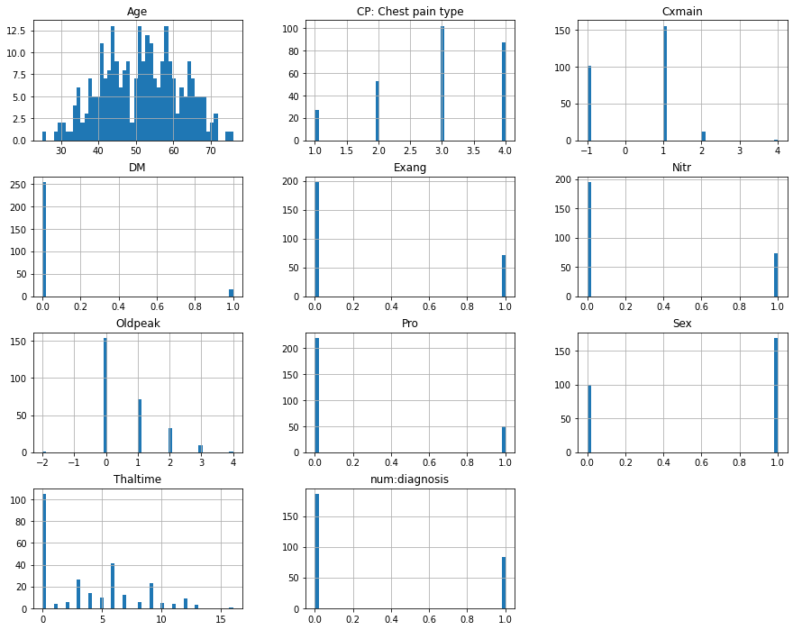

```python
df.hist(bins=50, figsize=(15, 12))
```

จาก output ด้านบนเป็นการแสดง histogram ของข้อมูล numeric ใน dataframe

```
array([<matplotlib.axes._subplots.AxesSubplot object at 0x00000149A7C6AA30>,
      dtype=object)
```

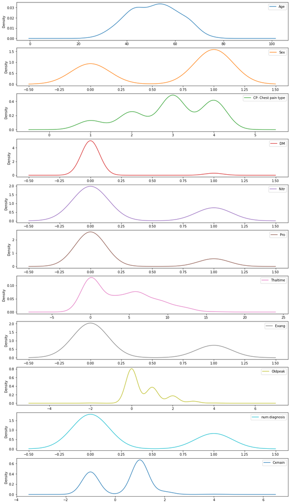

```python
df.plot(kind='density', subplots=True,figsize=(15, 28) ,sharex=False)
```

จาก output ด้านบนเป็นการแสดง line graph density ของข้อมูล numeric ใน dataframe

```
Age                       AxesSubplot(0.125,0.125;0.0596154x0.755)
Sex                    AxesSubplot(0.196538,0.125;0.0596154x0.755)
CP: Chest pain type    AxesSubplot(0.268077,0.125;0.0596154x0.755)
DM                     AxesSubplot(0.339615,0.125;0.0596154x0.755)
Nitr                   AxesSubplot(0.411154,0.125;0.0596154x0.755)
Pro                    AxesSubplot(0.482692,0.125;0.0596154x0.755)
Thaltime               AxesSubplot(0.554231,0.125;0.0596154x0.755)
Exang                  AxesSubplot(0.625769,0.125;0.0596154x0.755)
Oldpeak                AxesSubplot(0.697308,0.125;0.0596154x0.755)
num:diagnosis          AxesSubplot(0.768846,0.125;0.0596154x0.755)
Cxmain                 AxesSubplot(0.840385,0.125;0.0596154x0.755)
dtype: object
```

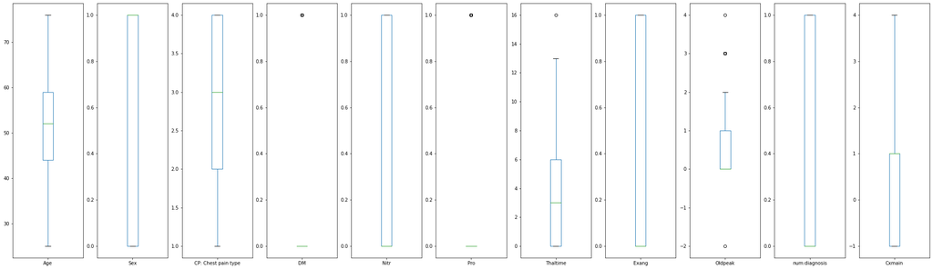

```python
df.plot(kind= 'box' , subplots=True, sharex=False, sharey=False, figsize=(35, 10))
```

จาก output ด้านบนเป็นการแสดง box plot ของข้อมูล numeric ใน dataframe

# หา Correlation ของ Attribute

```python
corr_matrix_pearson = df.corr(method='pearson')
corr_matrix_pearson
```

|  | Age | Sex | CP: Chest pain type | DM | Nitr | Pro | Thaltime | Exang | Oldpeak | num:diagnosis | Cxmain |
| --- | --- | --- | --- | --- | --- | --- | --- | --- | --- | --- | --- |
| Age | 1.000000 | -0.067730 | 0.149176 | 0.078433 | -0.008380 | -0.009526 | 0.135905 | 0.142868 | 0.195955 | 0.111788 | 0.413490 |
| Sex | -0.067730 | 1.000000 | 0.076860 | 0.086363 | 0.112127 | 0.064086 | 0.066106 | 0.094137 | 0.050742 | 0.330662 | 0.135768 |
| CP: Chest pain type | 0.149176 | 0.076860 | 1.000000 | 0.001950 | 0.082629 | 0.076898 | 0.105510 | 0.293199 | 0.073313 | 0.211622 | 0.208019 |
| DM | 0.078433 | 0.086363 | 0.001950 | 1.000000 | 0.067973 | 0.095183 | 0.003739 | 0.075015 | -0.023517 | 0.153338 | 0.130376 |
| Nitr | -0.008380 | 0.112127 | 0.082629 | 0.067973 | 1.000000 | 0.485721 | -0.132199 | 0.046620 | -0.025633 | 0.183244 | -0.044179 |
| Pro | -0.009526 | 0.064086 | 0.076898 | 0.095183 | 0.485721 | 1.000000 | -0.140942 | 0.001462 | -0.080534 | 0.185187 | -0.128179 |
| Thaltime | 0.135905 | 0.066106 | 0.105510 | 0.003739 | -0.132199 | -0.140942 | 1.000000 | 0.215035 | 0.422584 | 0.197977 | 0.299359 |
| Exang | 0.142868 | 0.094137 | 0.293199 | 0.075015 | 0.046620 | 0.001462 | 0.215035 | 1.000000 | 0.196679 | 0.312113 | 0.155896 |
| Oldpeak | 0.195955 | 0.050742 | 0.073313 | -0.023517 | -0.025633 | -0.080534 | 0.422584 | 0.196679 | 1.000000 | 0.183915 | 0.095953 |
| num:diagnosis | 0.111788 | 0.330662 | 0.211622 | 0.153338 | 0.183244 | 0.185187 | 0.197977 | 0.312113 | 0.183915 | 1.000000 | 0.112967 |
| Cxmain | 0.413490 | 0.135768 | 0.208019 | 0.130376 | -0.044179 | -0.128179 | 0.299359 | 0.155896 | 0.095953 | 0.112967 | 1.000000 |

```python
# 'Age','Sex','CP: Chest pain type','Trestbps','DM','Restecg','Prop','Nitr','Pro','Thaltime','Exang','Xhypo','Oldpeak','Cxmain'
```

```python
feature = df[['Age','Sex','CP: Chest pain type','DM','Nitr','Pro','Thaltime','Exang','Oldpeak','Cxmain']]
target = df['num:diagnosis']
```

```python
feature_train, feature_test, target_train, target_test = mod.train_test_split(feature, target, test_size =0.20,random_state= 0)
```

```python
feature_train2, feature_test2, target_train2, target_test2 = mod.train_test_split(feature, target, test_size =0.50,random_state= 0)
```

# Logistic Regression Method

### เมื่อแบ่งข้อมูลแบบ simple hold out ที่ให้ train:80 test:20

```python
model = LogisticRegression()
model.fit(feature_train, target_train)
predicted = model.predict(feature_test)
accuracy = accuracy_score(target_test, predicted)
print('accuracy = %.2f'%(accuracy))
```

```
accuracy = 0.78
```

```python
cm = confusion_matrix(target_test, predicted)
print(cm)
```

```
[[34  4]
 [ 8  8]]
```

```python
print(classification_report(target_test, predicted))
```

```
              precision    recall  f1-score   support

           0       0.81      0.89      0.85        38
           1       0.67      0.50      0.57        16

    accuracy                           0.78        54
   macro avg       0.74      0.70      0.71        54
weighted avg       0.77      0.78      0.77        54
```

### เมื่อแบ่งข้อมูลแบบ simple hold out ที่ให้ train:50 test:50

```python
model = LogisticRegression()
model.fit(feature_train2, target_train2)
predicted2 = model.predict(feature_test2)
accuracy = accuracy_score(target_test2, predicted2)
print('accuracy = %.2f'%(accuracy))
```

```
accuracy = 0.78
```

```python
cm = confusion_matrix(target_test2, predicted2)
print(cm)
```

```
[[84 10]
 [20 21]]
```

```python
print(classification_report(target_test2, predicted2))
```

```
              precision    recall  f1-score   support

           0       0.81      0.89      0.85        94
           1       0.68      0.51      0.58        41

    accuracy                           0.78       135
   macro avg       0.74      0.70      0.72       135
weighted avg       0.77      0.78      0.77       135
```

### เมื่อแบ่งข้อมูลแบบ cross-validation

```python
from sklearn import linear_model
model = linear_model.LogisticRegression(solver='liblinear')
acc_scores =  cross_val_score(model, feature, target, cv=10, scoring="accuracy")
print("Logistic Regression: Mean cross-validation accuracy = %.2f" % acc_scores.mean() )
```

```
Logistic Regression: Mean cross-validation accuracy = 0.72
```

### สรุป

- เมื่อแบ่งข้อมูลแบบ simple hold out ที่ให้ train:80 test:20 โมเดลมีค่า accuracy = 78%
- เมื่อแบ่งข้อมูลแบบ simple hold out ที่ให้ train:50 test:50 โมเดลมีค่า accuracy = 78%
- เมื่อแบ่งข้อมูลแบบ cross-validation โมเดลมีค่า accuracy = 72%

ดังนั้นการแบ่งข้อมูลแบบ simple hold out ที่ให้ train:80 test:20 และ train:50 test:50 จะได้โมเดล Logistic Regression ที่มีค่า accuracy มากที่สุด = 78%

# k-NN with k = 4

### เมื่อแบ่งข้อมูลแบบ simple hold out ที่ให้ train:80 test:20

```python
model = KNeighborsClassifier(n_neighbors=4)
model.fit(feature_train, target_train)
predicted = model.predict(feature_test)
accuracy = accuracy_score(target_test, predicted)
print('accuracy = %.2f'%(accuracy))
```

```
accuracy = 0.72
```

#### Confusion Matrix

```python
cm = confusion_matrix(target_test, predicted)
print(cm)
```

```
[[36  2]
 [13  3]]
```

#### Precision

```python
precision = metrics.precision_score(target_test, predicted)
print('precision = %.2f' %precision)
```

```
precision = 0.60
```

#### Recall

```python
recall = metrics.recall_score(target_test, predicted)
print('recall = %.2f' %recall)
```

```
recall = 0.19
```

```python
print(classification_report(target_test, predicted))
```

```
              precision    recall  f1-score   support

           0       0.73      0.95      0.83        38
           1       0.60      0.19      0.29        16

    accuracy                           0.72        54
   macro avg       0.67      0.57      0.56        54
weighted avg       0.69      0.72      0.67        54
```

### เมื่อแบ่งข้อมูลแบบ simple hold out ที่ให้ train:50 test:50

```python
model = KNeighborsClassifier(n_neighbors=4)
model.fit(feature_train2, target_train2)
predicted2 = model.predict(feature_test2)
accuracy = accuracy_score(target_test2, predicted2)
print('accuracy = %.2f'%(accuracy))
```

```
accuracy = 0.66
```

#### Confusion Matrix

```python
cm = confusion_matrix(target_test2, predicted2)
print(cm)
```

```
[[82 12]
 [34  7]]
```

#### Precision

```python
precision = metrics.precision_score(target_test2, predicted2)
print('precision = %.2f' %precision)
```

```
precision = 0.37
```

#### Recall

```python
recall = metrics.recall_score(target_test2, predicted2)
print('recall = %.2f' %recall)
```

```
recall = 0.17
```

```python
print(classification_report(target_test2, predicted2))
```

```
              precision    recall  f1-score   support

           0       0.71      0.87      0.78        94
           1       0.37      0.17      0.23        41

    accuracy                           0.66       135
   macro avg       0.54      0.52      0.51       135
weighted avg       0.60      0.66      0.61       135
```

### เมื่อแบ่งข้อมูลแบบ cross-validation

```python
# create a single classifier
model = KNeighborsClassifier(n_neighbors=4)
# apply 2-fold cross-validation, measuring accuracy each time
#from sklearn.model_selection import cross_val_score
acc_scores = cross_val_score(model, feature, target, cv=10, scoring="accuracy")
print("KNN: Mean cross-validation accuracy = %.2f" % acc_scores.mean() )
```

```
KNN: Mean cross-validation accuracy = 0.65
```

### สรุป

- เมื่อแบ่งข้อมูลแบบ simple hold out ที่ให้ train:80 test:20 โมเดลมีค่า accuracy = 72%
- เมื่อแบ่งข้อมูลแบบ simple hold out ที่ให้ train:50 test:50 โมเดลมีค่า accuracy = 66%
- เมื่อแบ่งข้อมูลแบบ cross-validation โมเดลมีค่า accuracy = 65%

ดังนั้นการแบ่งข้อมูลแบบ simple hold out ที่ให้ train:80 test:20 จะได้โมเดล KNN ที่มีค่า accuracy มากที่สุด = 72%

# SVM Method

### เมื่อแบ่งข้อมูลแบบ simple hold out ที่ให้ train:80 test:20

```python
model = svm.SVC(C=2, gamma='scale', kernel='linear')
model.fit(feature_train, target_train)
predicted = model.predict(feature_test)
accuracy = accuracy_score(target_test, predicted)
print('accuracy = %.2f'%(accuracy))
```

```
accuracy = 0.78
```

#### Confusion Matrix

```python
cm = confusion_matrix(target_test, predicted)
print(cm)
```

```
[[34  4]
 [ 8  8]]
```

#### Precision

```python
precision = metrics.precision_score(target_test, predicted)
print('precision = %.2f' %precision)
```

```
precision = 0.67
```

#### Recall

```python
recall = metrics.recall_score(target_test, predicted)
print('recall = %.2f' %recall)
```

```
recall = 0.50
```

```python
print(classification_report(target_test, predicted))
```

```
              precision    recall  f1-score   support

           0       0.81      0.89      0.85        38
           1       0.67      0.50      0.57        16

    accuracy                           0.78        54
   macro avg       0.74      0.70      0.71        54
weighted avg       0.77      0.78      0.77        54
```

### เมื่อแบ่งข้อมูลแบบ simple hold out ที่ให้ train:50 test:50

```python
model = svm.SVC(C=2, gamma='scale', kernel='linear')
model.fit(feature_train2, target_train2)
predicted2 = model.predict(feature_test2)
accuracy = accuracy_score(target_test2, predicted2)
print('accuracy = %.2f'%(accuracy))
```

```
accuracy = 0.79
```

#### Confusion Matrix

```python
cm = confusion_matrix(target_test2, predicted2)
print(cm)
```

```
[[79 15]
 [14 27]]
```

#### Precision

```python
recision = metrics.precision_score(target_test2, predicted2)
print('precision = %.2f' %precision)
```

[output not shown]

#### Recall

```python
recall = metrics.recall_score(target_test2, predicted2)
print('recall = %.2f' %recall)
```

```
recall = 0.66
```

```python
print(classification_report(target_test2, predicted2))
```

```
              precision    recall  f1-score   support

           0       0.85      0.84      0.84        94
           1       0.64      0.66      0.65        41

    accuracy                           0.79       135
   macro avg       0.75      0.75      0.75       135
weighted avg       0.79      0.79      0.79       135
```

### เมื่อแบ่งข้อมูลแบบ cross-validation

```python
model = SVC(gamma='scale')
acc_scores = cross_val_score(model, feature, target, cv=10, scoring="accuracy")
print("SVM: Mean cross-validation accuracy = %.2f" % acc_scores.mean() )
```

```
SVM: Mean cross-validation accuracy = 0.69
```

### สรุป

- เมื่อแบ่งข้อมูลแบบ simple hold out ที่ให้ train:80 test:20 โมเดลมีค่า accuracy = 78%
- เมื่อแบ่งข้อมูลแบบ simple hold out ที่ให้ train:50 test:50 โมเดลมีค่า accuracy = 79%
- เมื่อแบ่งข้อมูลแบบ cross-validation โมเดลมีค่า accuracy = 69%

ดังนั้นการแบ่งข้อมูลแบบ simple hold out ที่ให้ train:50 test:50 จะได้โมเดล SVM ที่มีค่า accuracy มากที่สุด = 79%

# Decision Tree Method

### เมื่อแบ่งข้อมูลแบบ simple hold out ที่ให้ train:80 test:20

```python
from sklearn.tree import DecisionTreeClassifier
model = DecisionTreeClassifier()
model.fit(feature_train, target_train)
predicted = model.predict(feature_test)
accuracy = accuracy_score(target_test, predicted)
print('accuracy = %.2f'%(accuracy))
```

```
accuracy = 0.72
```

#### Confustion Matrix

```python
cm = confusion_matrix(target_test, predicted)
print(cm)
```

```
[[32  6]
 [ 9  7]]
```

#### Precision

```python
precision = metrics.precision_score(target_test, predicted)
print('precision = %.2f' %precision)
```

```
precision = 0.54
```

#### Recall

```python
recall = metrics.recall_score(target_test, predicted)
print('recall = %.2f' %recall)
```

```
recall = 0.44
```

```python
print(classification_report(target_test, predicted))
```

```
              precision    recall  f1-score   support

           0       0.78      0.84      0.81        38
           1       0.54      0.44      0.48        16

    accuracy                           0.72        54
   macro avg       0.66      0.64      0.65        54
weighted avg       0.71      0.72      0.71        54
```

### เมื่อแบ่งข้อมูลแบบ simple hold out ที่ให้ train:50 test:50

```python
from sklearn.tree import DecisionTreeClassifier
model = DecisionTreeClassifier()
model.fit(feature_train2, target_train2)
predicted2 = model.predict(feature_test2)
accuracy = accuracy_score(target_test2, predicted2)
print('accuracy = %.2f'%(accuracy))
```

```
accuracy = 0.71
```

#### Confusion Matrix

```python
cm = confusion_matrix(target_test2, predicted2)
print(cm)
```

```
[[72 22]
 [17 24]]
```

#### Precision

```python
precision = metrics.precision_score(target_test2, predicted2)
print('precision = %.2f' %precision)
```

```
precision = 0.52
```

#### Recall

```python
recall = metrics.recall_score(target_test2, predicted2)
print('recall = %.2f' %recall)
```

```
recall = 0.59
```

```python
print(classification_report(target_test2, predicted2))
```

```
              precision    recall  f1-score   support

           0       0.81      0.77      0.79        94
           1       0.52      0.59      0.55        41

    accuracy                           0.71       135
   macro avg       0.67      0.68      0.67       135
weighted avg       0.72      0.71      0.72       135
```

### เมื่อแบ่งข้อมูลแบบ cross-validation

```python
model = DecisionTreeClassifier()
acc_scores = cross_val_score(model, feature, target, cv=10, scoring="accuracy")
print("Dicision Tree : Mean cross-validation accuracy = %.2f" % acc_scores.mean() )
```

```
Dicision Tree : Mean cross-validation accuracy = 0.71
```

### สรุป

- เมื่อแบ่งข้อมูลแบบ simple hold out ที่ให้ train:80 test:20 โมเดลมีค่า accuracy = 72%
- เมื่อแบ่งข้อมูลแบบ simple hold out ที่ให้ train:50 test:50 โมเดลมีค่า accuracy = 71%
- เมื่อแบ่งข้อมูลแบบ cross-validation โมเดลมีค่า accuracy = 71%

ดังนั้นการแบ่งข้อมูลแบบ simple hold out ที่ให้ train:80 test:20 จะได้โมเดล Dicision Tree ที่มีค่า accuracy มากที่สุด = 72%

# Neural Network (NN) Method

### เมื่อแบ่งข้อมูลแบบ simple hold out ที่ให้ train:80 test:20

```python
model = Sequential()
model.add(Dense(15 ,activation='relu',input_shape=(feature_train.shape[1:])))
model.add(Dense(5, activation='softmax'))
opt = tf.keras.optimizers.Adam(lr=0.001, decay=0.00001)
model.compile(
    loss= "sparse_categorical_crossentropy",
    optimizer=opt,
    metrics='accuracy',
)
model.fit(feature_train, target_train, epochs=30, batch_size = 15)
predicted = model.predict(feature_test)
```

```python
test = tf.argmax(predicted, axis=1).numpy()
accuracy = accuracy_score(target_test, test)
print('accuracy = %.2f'%(accuracy))
```

```
accuracy = 0.80
```

#### Confusion Matrix

```python
cm = confusion_matrix(target_test, test)
print(cm)
```

```
[[33  5]
 [ 6 10]]
```

#### Precision

```python
precision = metrics.precision_score(target_test, test)
print('precision = %.2f' %precision)
```

```
precision = 0.67
```

#### Recall

```python
recall = metrics.recall_score(target_test, test)
print('recall = %.2f' %recall)
```

```
recall = 0.62
```

```python
print(classification_report(target_test, test))
```

```
              precision    recall  f1-score   support

           0       0.85      0.87      0.86        38
           1       0.67      0.62      0.65        16

    accuracy                           0.80        54
   macro avg       0.76      0.75      0.75        54
weighted avg       0.79      0.80      0.79        54
```

### เมื่อแบ่งข้อมูลแบบ simple hold out ที่ให้ train:50 test:50

```python
model = Sequential()
model.add(Dense(15 ,activation='relu',input_shape=(feature_train2.shape[1:])))
model.add(Dense(2, activation='softmax'))
opt = tf.keras.optimizers.Adam(lr=0.001, decay=0.00001)
model.compile(
    loss= "sparse_categorical_crossentropy",
    optimizer=opt,
    metrics='accuracy',
)
model.fit(feature_train2, target_train2, epochs=30, batch_size = 15)
predicted2 = model.predict(feature_test2)
```

```python
test = tf.argmax(predicted2, axis=1).numpy()
accuracy = accuracy_score(target_test2, test)
print('accuracy = %.2f'%(accuracy))
```

```
accuracy = 0.63
```

#### Precision

```python
precision = metrics.precision_score(target_test2, test)
print('precision = %.2f' %precision)
```

```
precision = 0.20
```

#### Recall

```python
recall = metrics.recall_score(target_test2, test)
print('recall = %.2f' %recall)
```

```
recall = 0.07
```

```python
print(classification_report(target_test2, test))
```

```
              precision    recall  f1-score   support

           0       0.68      0.87      0.77        94
           1       0.20      0.07      0.11        41

    accuracy                           0.63       135
   macro avg       0.44      0.47      0.44       135
weighted avg       0.54      0.63      0.57       135
```

### สรุป

- เมื่อแบ่งข้อมูลแบบ simple hold out ที่ให้ train:80 test:20 โมเดลมีค่า accuracy = 80%
- เมื่อแบ่งข้อมูลแบบ simple hold out ที่ให้ train:50 test:50 โมเดลมีค่า accuracy = 63%

ดังนั้นการแบ่งข้อมูลแบบ simple hold out ที่ให้ train:80 test:20 จะได้โมเดล Neural Network (NN) ที่มีค่า accuracy มากที่สุด = 80%

การแบ่งข้อมูลแบบ simple hold out ที่ให้ train:80 test:20 และ train:50 test:50 จะได้โมเดล Logistic Regression ที่มีค่า accuracy มากที่สุด = 78%

การแบ่งข้อมูลแบบ simple hold out ที่ให้ train:80 test:20 จะได้โมเดล KNN ที่มีค่า accuracy มากที่สุด = 72%

การแบ่งข้อมูลแบบ simple hold out ที่ให้ train:50 test:50 จะได้โมเดล SVM ที่มีค่า accuracy มากที่สุด = 79%

การแบ่งข้อมูลแบบ imple hold out ที่ให้ train:80 test:20 จะได้โมเดล Decision Tree ที่มีค่า accuracy มากที่สุด = 72%

การแบ่งข้อมูลแบบ simple hold out ที่ให้ train:80 test:20 จะได้โมเดล Neural Network (NN) ที่มีค่า accuracy มากที่สุด = 80%

ดังนั้นการแบ่งข้อมูลแบบ simple hold out ที่ให้ train:80 test:20 จะได้โมเดล Neural Network (NN) ที่มีค่า accuracy มากที่สุด = 80%

# Reference

Detrano, R., Janosi, A., Steinbrunn, W., Pfisterer, M., Schmid, J., Sandhu, S., Guppy, K., Lee, S., & Froelicher, V. (1989). International application of a new probability algorithm for the diagnosis of coronary artery disease. American Journal of Cardiology, 64,304--310. [Web Link]

David W. Aha & Dennis Kibler. "Instance-based prediction of heart-disease presence with the Cleveland database." [Web Link]

Gennari, J.H., Langley, P, & Fisher, D. (1989). Models of incremental concept formation. Artificial Intelligence, 40, 11--61. [Web Link]